# Semana de Desenvolvimento Docente

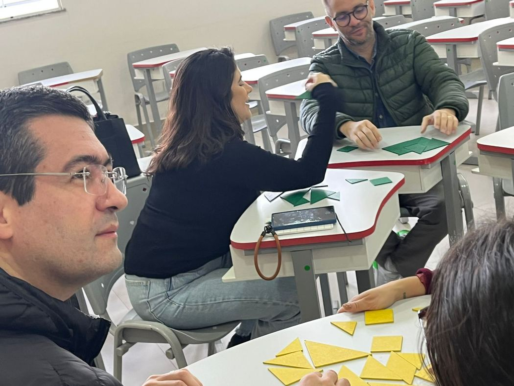

Alinhamento IESC (Medicina)

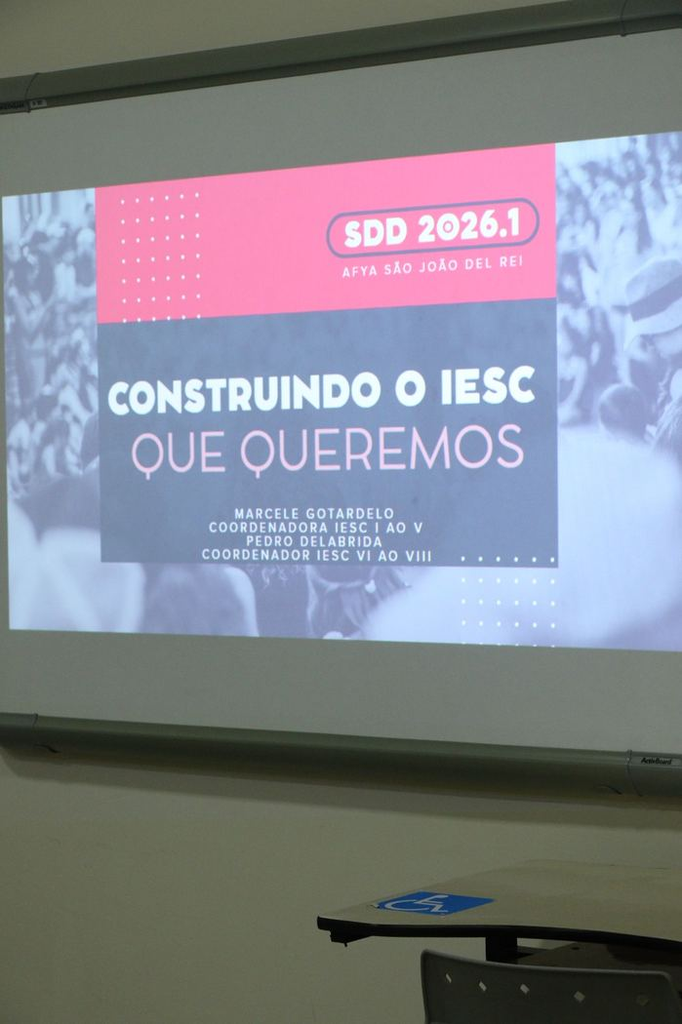

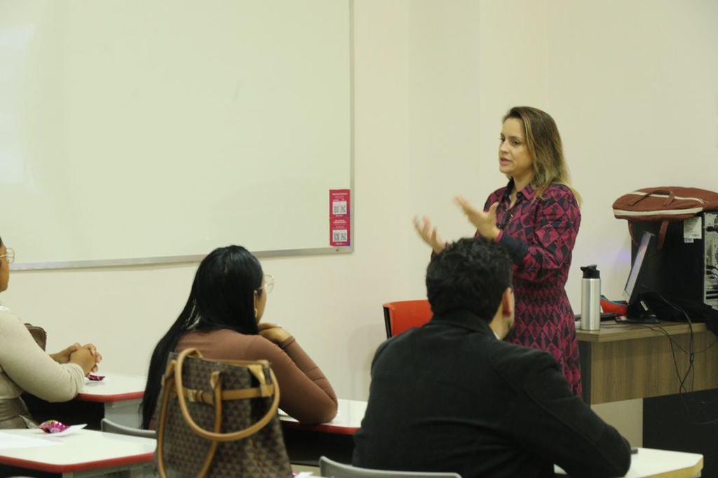

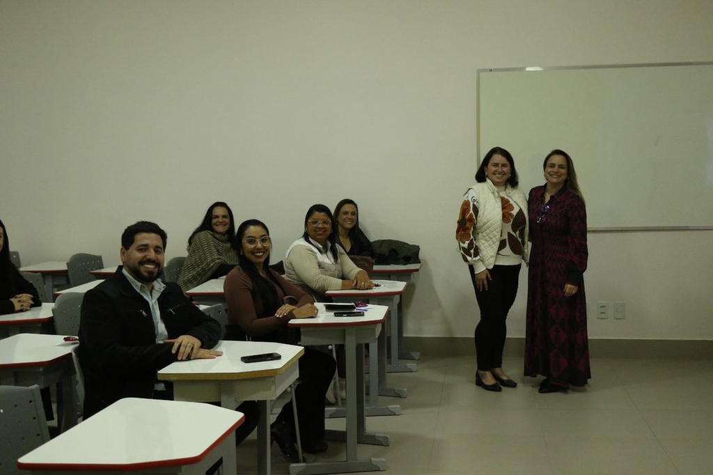

Treinamento ENADE

[figure not shown]

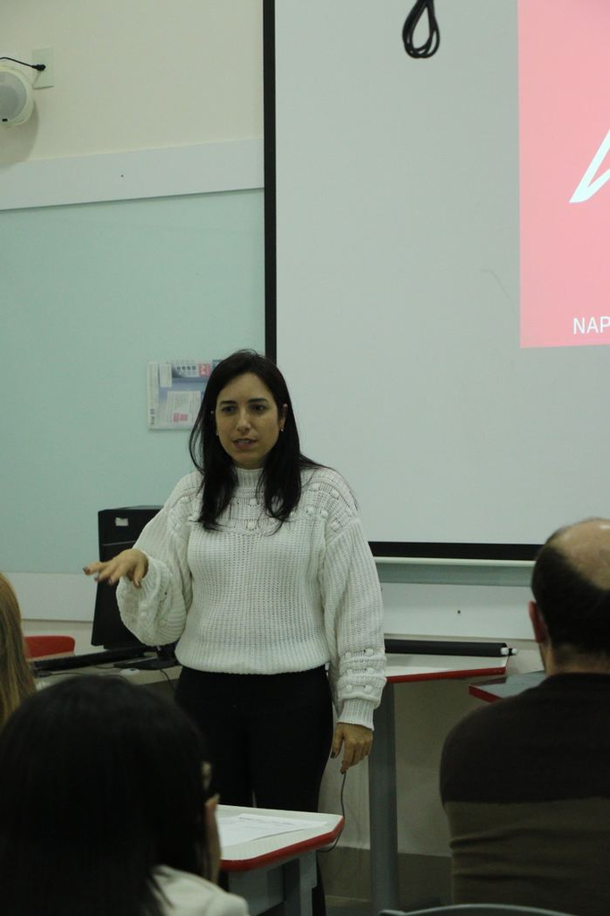

Alinhamento C.I. (Medicina)

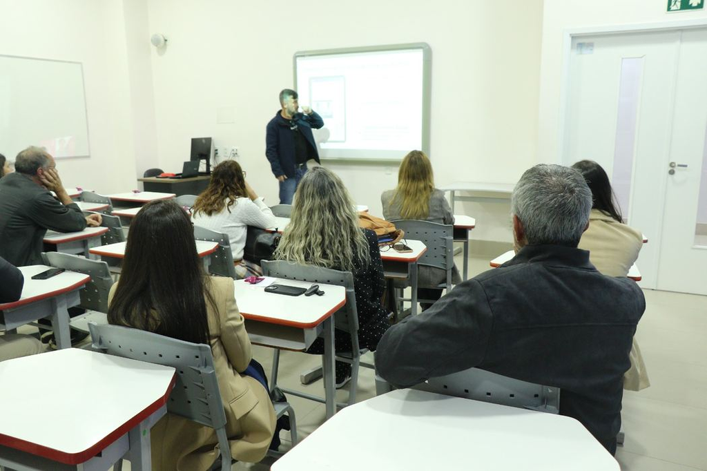

[figure not shown]

Oficina de feedback — Cursos SHE

[figure not shown]

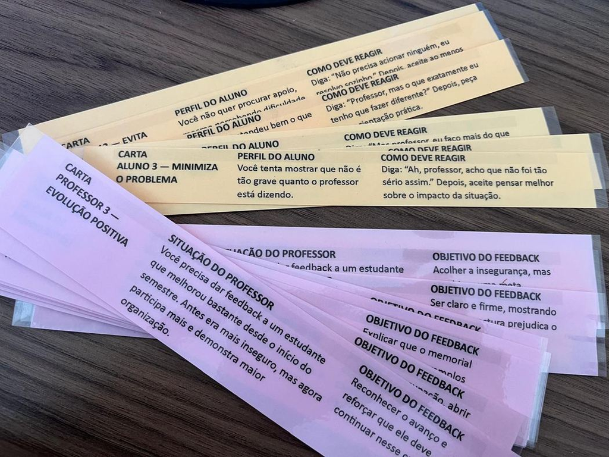

4

Qui · 09/07

### Confraternização e celebração

Para encerrar, a **Noite de Confraternização** reuniu todos no Bar Real, num rodízio de pizzas (19h) — um momento de celebrar a semana e fortalecer os laços da equipe, com muito calor humano mesmo no frio de julho.

Registros do dia

[figure not shown]

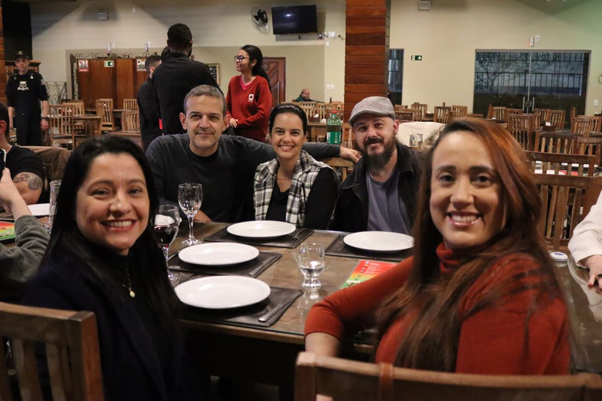

[figure not shown]

[figure not shown]

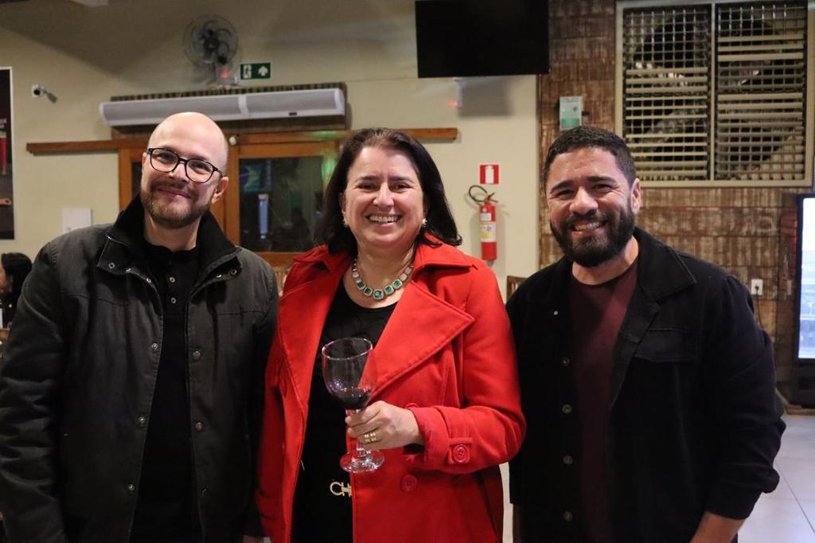

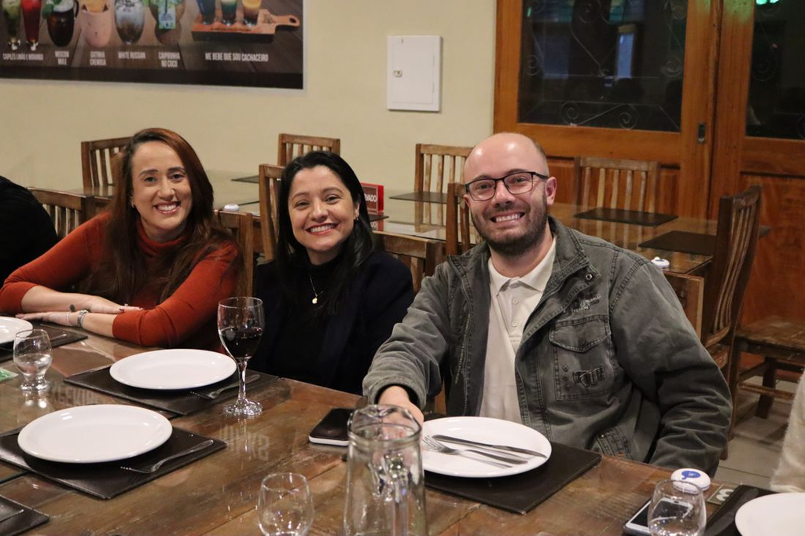

[figure not shown]

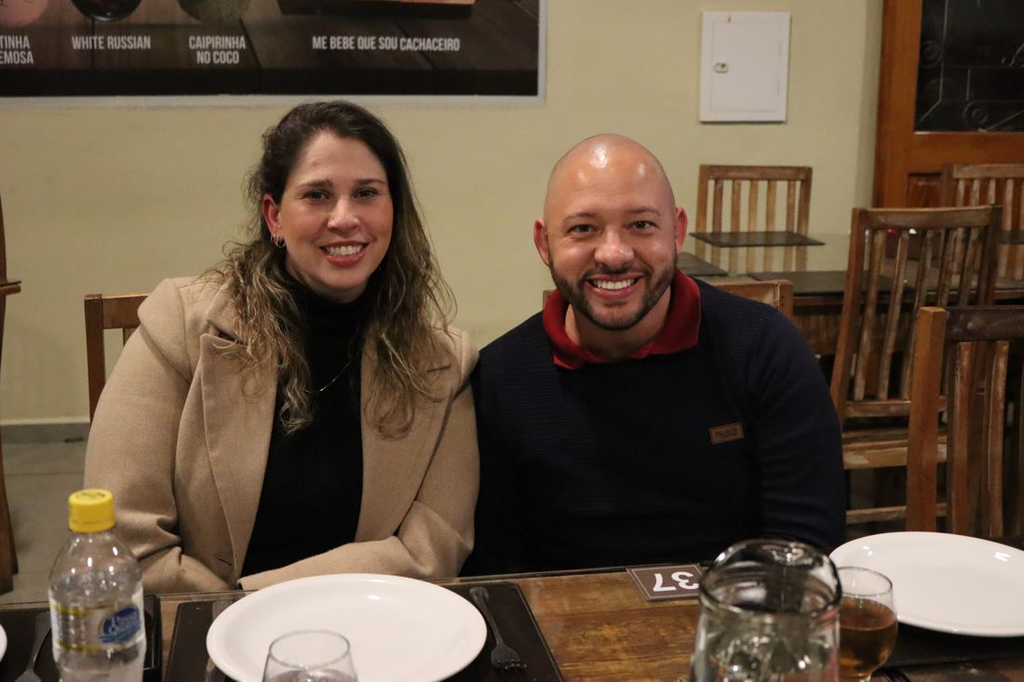

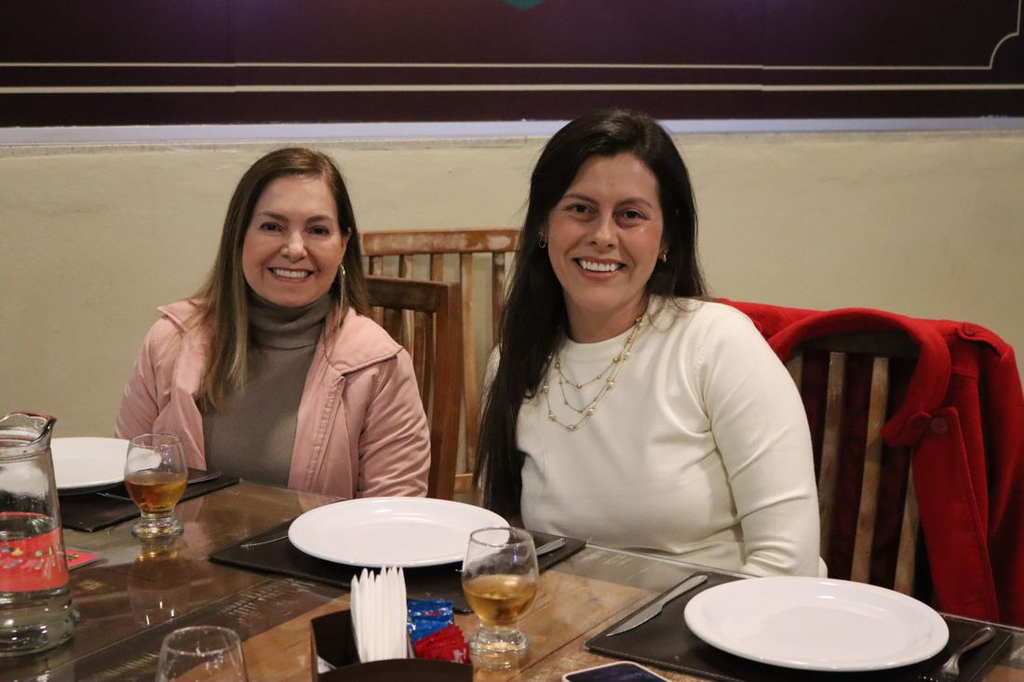

[figure not shown]

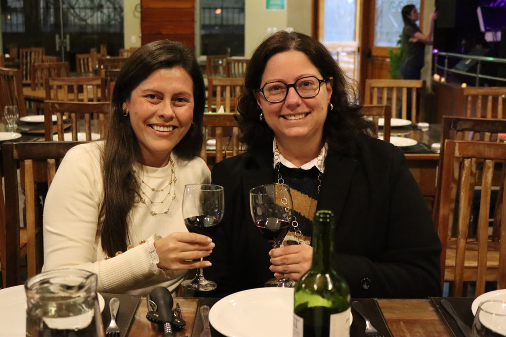

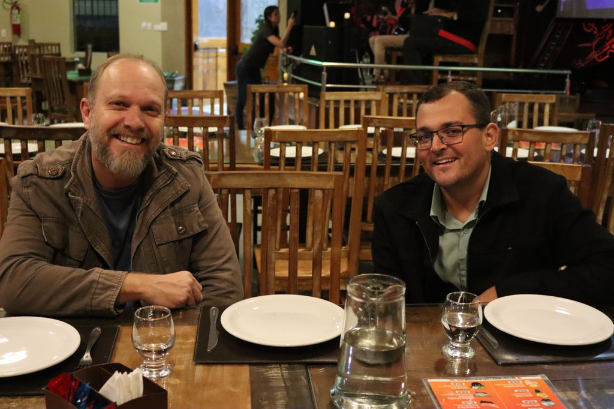

[4 more figures not shown]

Novidade desta edição

## Boa prática docente

### O começo de um acervo de boas práticas

Mais do que um registro do semestre, a proposta é construir um acervo institucional de boas práticas docentes — ponto de partida para futuras publicações, projetos e reconhecimentos acadêmicos que valorizem a docência na Afya São João del-Rei.

Para onde queremos levar

Publicações Projetos Reconhecimentos acadêmicos

Vozes da semana

## O que disseram os participantes

“

Os momentos dedicados a cada curso proporcionaram o surgimento de muitas ideias e aprendizagens.

**Kelly Jackeline Oliveira Pereira Andrade**Docente · Afya SJDR

“

Usar a SDD para fazermos a reunião interna dos cursos e resolver demandas específicas foi muito proveitoso e extremamente aplicável. Poderiam manter nesse formato.

**Douglas Roberto Guimarães Silva**Docente · Afya SJDR

“

O encerramento, feito junto, foi muito legal. Minha sugestão é ter um momento de abertura com todos e, depois, cada curso seguindo a sua própria programação conforme a necessidade.

**Wagner Elias de Melo Moreira**Docente · Afya SJDR

Navegar pelo portfólio